# Linear Models

# Summary

- Bivariate data: data that involves two variables.
- Scatter plot: a graphical summary of two variables on the same 2D plane, resulting in a cloud of points.
- Linear association: Between two variables, measure how tightly the points cluster around a line **where if there is a strong association**, the cloud of the points will be tightly clustered around a line (i.e. one variable may be used to predict the other)
- Correlation coefficient (*r*): measures the clustering around the line and indicates both the sign and strength of the linear association.
  - Lies between -1 and +1 where if *r* = +/-1, there is perfect correlation (i.e. all the points lie on the line).
  - When *r* = 0, there is no correlation.
  - *r* is a pure number (no units)
  - A positive *r* means a positive correlation, and a negative *r* a negative.
- Regression line uses 5 numerical summaries:
  - Mean of *x*
  - Mean of *y*
  - SD of *x*
  - SD of *y*
  - *r*

At the end of this Lab, you should be able to examine the relationships between variables using *correlation* and *visualization*, and justify whether regression is an appropriate model for the data (L04)

# Statistical Thinking

Let’s randomize some data to generate an x-y relationship.

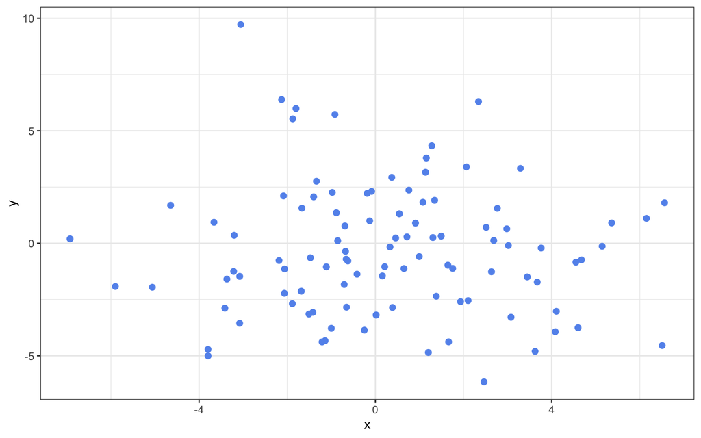

```r
set.seed(123) # Making sure random happens in a same boat.
df <- tibble(x = rnorm(100, 0, 3), y = rnorm(100, 0, 3))

ggplot(df, aes(x, y)) +
  geom_point(size = 2, colour = "cornflowerblue") +
  theme_bw()
```

5 elements:

```r
x_avg <- sum(df$x) / 100
x_mean <- mean(df$x)
x_sd <- sd(df$x)
y_avg <- sum(df$y) / 100
y_mean <- mean(df$y)
y_sd <- sd(df$y)

knitr::kable(tibble(x_avg, x_mean, x_sd, y_avg, y_mean, y_sd, cor = cor(df$x,df$y)), align = "cc")
```

| x_avg | x_mean | x_sd | y_avg | y_mean | y_sd | cor |
| --- | --- | --- | --- | --- | --- | --- |
| 0.2712177 | 0.2712177 | 2.738448 | -0.3226404 | -0.3226404 | 2.90096 | -0.0495321 |

2. Given these options: -1, nearly -1, somewhat negative, 0, somewhat positive, nearly 1 and 1; what is the correlation between (with a short explanation):
   1. A person’s age and their year of birth? Should be 1
   2. The price of a car and time? Should be nearly -1
3. Given that the *family’s income = husband’s income + wife’s income*, and using the same options as in Q2; what is the correlation between (with a short explanation):
   1. The wife’s income and the family income? Should be nearly 1
   2. The wife’s income and the husband’s income? Should be 0
4. True or False: if $r = 0.90$, then 90% of the points are highly correlated.
5. Given the small data set below; $r \approx\ 0.76$
   1. If you switch the two columns, does this change *r*?
   2. If you add 3 to each value of *y*, does this change *r*?
   3. Justify in R.

```r
data.frame(xvar = c(1:5), yvar = c(2, 3, 1, 5, 6))
```

```
##   xvar yvar
## 1    1    2
## 2    2    3
## 3    3    1
## 4    4    5
## 5    5    6
```

# Demo

## Olympic 100m sprint

### Domain knowledge

The 100 m men sprint is considered one of the most prestigious events at each Olympics. Who holds the current world record time for men, and what was his time? [Olympic times](https://www.olympic.org/athletics/100m-men).

Let’s dive into our own data set.

```r
olympics <- read_csv("data/Olympics100m.csv")
glimpse(olympics) # check structure
```

```
## Rows: 50
## Columns: 7
## $ Year    <dbl> 1896, 1900, 1904, 1906, 1908, 1912, 1920, 1924, 1928, 1932, 19…
## $ ...2    <chr> "Tom Burke", "Frank Jarvis", "Archie Hahn", "Archie Hahn", "Re…
## $ Time    <dbl> 12.00, 11.00, 11.00, 11.20, 10.80, 10.80, 10.80, 10.60, 10.80,…
## $ Country <chr> "USA", "USA", "USA", "USA", "SAF", "USA", "USA", "GBR", "CAN",…
## $ Gender  <chr> "male", "male", "male", "male", "male", "male", "male", "male"…
## $ ...6    <lgl> NA, NA, NA, NA, NA, NA, NA, NA, NA, NA, NA, NA, NA, NA, NA, NA…
## $ ...7    <lgl> NA, NA, NA, NA, NA, NA, NA, NA, NA, NA, NA, NA, NA, NA, NA, NA…
```

While it is an *optional* step, cleaning the data can lead to faster processing times (and less confusion about variable names). What “problems” can you observe in the `olympics` data?

```r
# Cleaning is important
olym <-
  olympics %>%
  rename(name = 2) %>% # rename a column
  select(-6, -7) %>%   # discard columns with `-` - useless cols
  janitor::clean_names()  # make col names lower-cased and regulated

glimpse(olym) # what has changed?
```

```
## Rows: 50
## Columns: 5
## $ year    <dbl> 1896, 1900, 1904, 1906, 1908, 1912, 1920, 1924, 1928, 1932, 19…
## $ name    <chr> "Tom Burke", "Frank Jarvis", "Archie Hahn", "Archie Hahn", "Re…
## $ time    <dbl> 12.00, 11.00, 11.00, 11.20, 10.80, 10.80, 10.80, 10.60, 10.80,…
## $ country <chr> "USA", "USA", "USA", "USA", "SAF", "USA", "USA", "GBR", "CAN",…
## $ gender  <chr> "male", "male", "male", "male", "male", "male", "male", "male"…
```

Let’s explore the data with `plot()`.

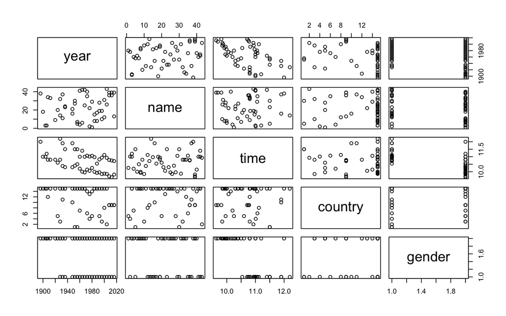

```r
plot(olym)
```

What patterns can we see?

- There are factors
- Countries biased
- Year and time

How many gold medal records are won each year?

```r
olym %>%
  pull(year) %>% # Get attribute and all its appearances
  table()  # why do some years have 2 counts while others have only 1?
```

```
## .
## 1896 1900 1904 1906 1908 1912 1920 1924 1928 1932 1936 1948 1952 1956 1960 1964
##    1    1    1    1    1    1    1    1    2    2    2    2    2    2    2    2
## 1968 1972 1976 1980 1984 1988 1992 1996 2000 2004 2008 2012 2016
##    2    2    2    2    2    2    2    2    2    2    2    2    2
```

From the output above we can observe that before 1928, only one winning time was recorded instead of two. What is causing this pattern?

```r
olym %>%
  group_by(gender) %>%
  summarise(total = sum(n())) %>% # count rows per group
  knitr::kable(caption = "Table 1: Total world records from 1896 - 2016.", align = "cc")
```

Table 1: Total world records from 1896 - 2016.

| gender | total |
| --- | --- |
| female | 21 |
| male | 29 |

Note that up to this point, we are still exploring the data for insights.

### Univariate exploration

Please look through this section at your own time as we will only briefly go through the steps.

> When was the men’s slowest race time? How does it compare to the women’s fastest time?

```r
olym %>%
  filter(gender == "male") %>%
  select(time) %>%
  max()
```

```
## [1] 12
```

```r
olym %>%
  filter(gender == "female") %>%
  select(time) %>%
  min()
```

```
## [1] 10.54
```

```r
olym %>%
  group_by(gender) %>%
  summarise(max = max(time),
            min = min(time)) %>%
  gt::gt()
```

| gender | max | min |
| --- | --- | --- |
| female | 12.2 | 10.54 |
| male | 12.0 | 9.63 |

> Which country has the most winning records?

To answer this question, we need to sort by country and count the rows.

```r
most_gold <-
  olym %>%
  group_by(country) %>%
  tally() %>%
  arrange(desc(n))

most_gold
```

```
## # A tibble: 15 × 2
##    country     n
##    <chr>   <int>
##  1 USA        26
##  2 JAM         6
##  3 GBR         3
##  4 AUS         2
##  5 CAN         2
##  6 URS         2
##  7 BLR         1
##  8 FRG         1
##  9 GDR         1
## 10 GER         1
## 11 GRE         1
## 12 NED         1
## 13 POL         1
## 14 SAF         1
## 15 TRI         1
```

The output shows that the most winning records go to USA.

Plotting the data would probably be nicer!

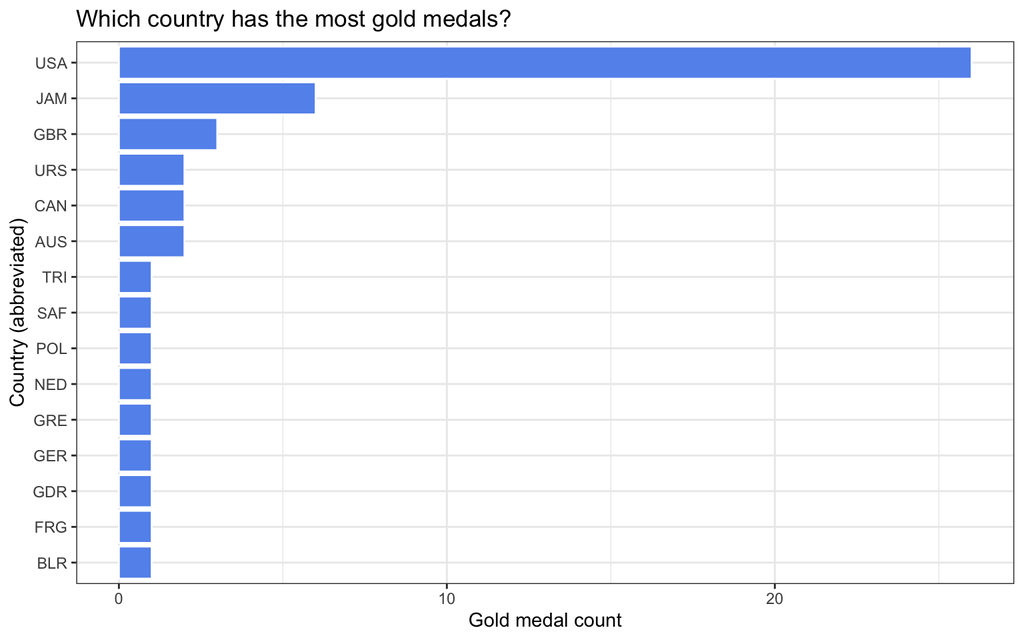

```r
most_gold %>%
  # slice(1:6) %>%
  ggplot(aes(n, reorder(country, n))) +
  geom_bar(stat = "identity", colour = "white", fill = "cornflowerblue") +
  theme_bw() +
  xlab("Gold medal count") +
  ylab("Country (abbreviated)") +
  ggtitle("Which country has the most gold medals?")
```

We might group all the countries having 1 gold medal, but plz don’t remove it.

### Bivariate relationships

> What pattern can we observe when we plot men’s winning time (`time`) with `year`?dw

Eventually, we want to move beyond simple summary statistics and start to compare between variables.

- Construct a linear model between winning time and year for men. Using the model, predict the winning time for the 2021 Olympics (delayed due to COVID-19). Is this reliable?
- Your research question concerning a linear model should involve 2 quantitative/continuous variables. *Does the data fit the requirement?*

We will:

1. Generate the scatter plot and check correlation;
2. Fit a linear model on the data;
3. Check assumptions;
4. Interpret the results;
5. Update the plot with the model;
6. Make a prediction (optional).

### **Step 1**: generate the scatter plot and check correlation

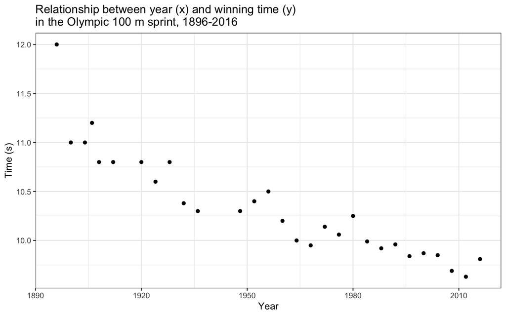

```r
male_time <-
  olym %>%
  filter(gender == "male") %>%
  select(year, time)

p1 <-
  ggplot(male_time, aes(year, time)) +
  geom_point() +
  theme_bw() +
  xlab("Year") +
  ylab("Time (s)") +
  ggtitle("Relationship between year (x) and winning time (y)\nin the Olympic 100 m sprint, 1896-2016") # note how we can wrap the text using `\n`

p1
```

```r
# check correlation
cor(male_time)
```

```
##            year       time
## year  1.0000000 -0.9114649
## time -0.9114649  1.0000000
```

### **Step 2**: fit a linear model

Linear models are constructed using the `lm()` function. Note that we use the formula `y ~ x` to express a relationship between `x` and `y`.

What is the formula?

- Formula (bi-variate relationship)
- y ~ x (tilde)
- y is a function of x (f(x)), y is the predicting value
- y can be influenced by predictor x
- For any relationship, define such function y ~ x

```r
# lm(y ~ x, data)
# Also t.test, chisq... and tidymodules!
fit <- lm(time ~ year, male_time)
fit
```

```
##
## Call:
## lm(formula = time ~ year, data = male_time)
##
## Coefficients:
## (Intercept)         year
##    35.65353     -0.01293
```

### **Step 3**: check assumptions

Before proceeding, it is important to check if the data meets the assumptions of a linear model. These following assumptions apply:

- independence of x and y
- data meets assumption of normality
- data meets assumption of homogeneity of variances (equal variances)
  - Making sure that distance between entries to the lm line is somehow equal distanced.

Warning: the model produces results even if assumptions are not met!

We can simply `plot()` the model object to check these assumptions from the residuals produced by the model.

- First plot: check for linearity and equal variances
- Second plot: check for normality
- Third plot: check for equal variances
- Fourth plot: check for important outlines

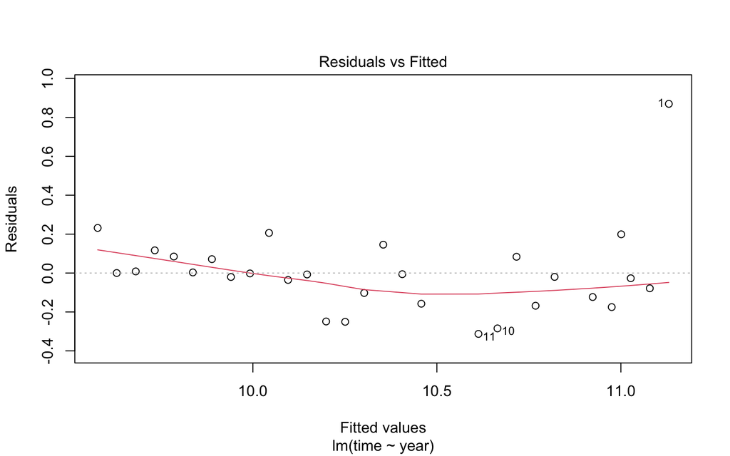

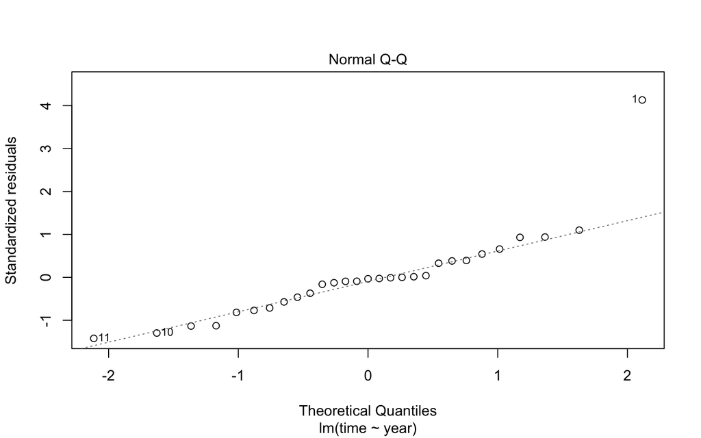

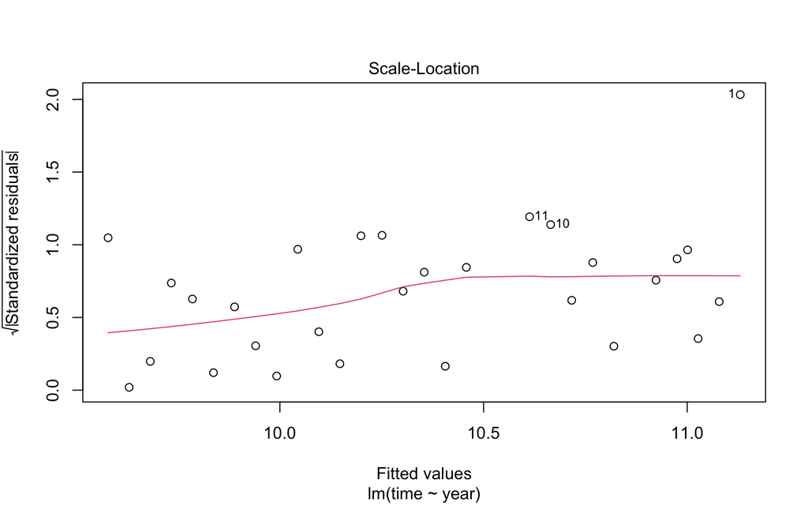

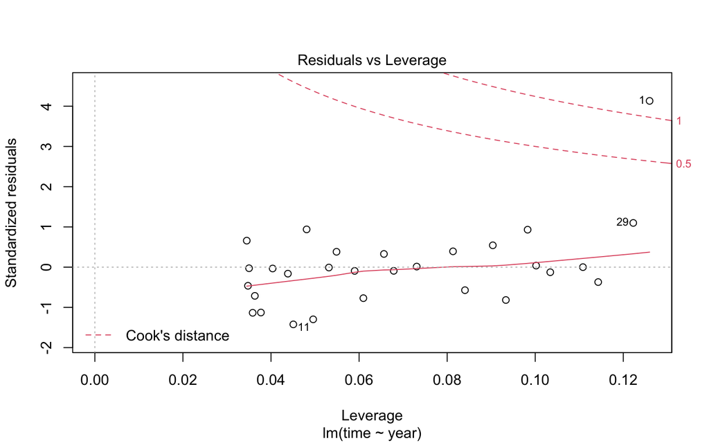

```r
plot(fit)
```

### **Step 4**: interpret the results

Using the `summary()` function allows us to check the model output including R<sup>2</sup> and p-value.

```r
summary(fit)
```

```
##
## Call:
## lm(formula = time ~ year, data = male_time)
##
## Residuals:
##      Min       1Q   Median       3Q      Max
## -0.31292 -0.12334 -0.00729  0.08361  0.86971
##
## Coefficients:
##              Estimate Std. Error t value Pr(>|t|)
## (Intercept) 35.653534   2.198588   16.22 1.92e-15 ***
## year        -0.012934   0.001123  -11.51 6.37e-12 ***
## ---
## Signif. codes:  0 '***' 0.001 '**' 0.01 '*' 0.05 '.' 0.1 ' ' 1
##
## Residual standard error: 0.2252 on 27 degrees of freedom
## Multiple R-squared:  0.8308, Adjusted R-squared:  0.8245
## F-statistic: 132.5 on 1 and 27 DF,  p-value: 6.368e-12
```

Note: if the model does not meet the assumptions, we should NOT proceed to this step.

The results show that there is a significant linear relationship between sprint time and year (R<sup>2</sup> = 0.8, p < 0.01).

### **Step 5**: Update the plot

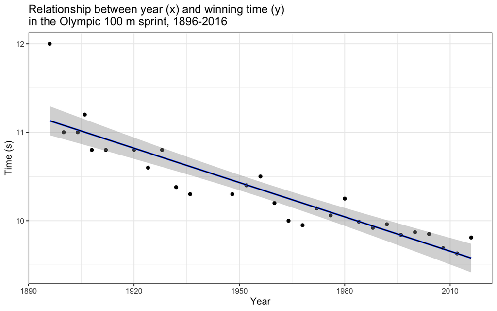

```r
p1 +
  geom_smooth(method = "lm") +
  geom_line(aes(y = predict(fit))) # Own line in own made prediction with own function
```

### **Step 6**: predict (optional)

Should we use this relationship to make a prediction for 2021? What about 2024?

```r
predict(fit, newdata = data.frame(year = c(2021, 2024)))
```

```
##        1        2
## 9.513512 9.474709
```

It is often dangerous to predict outside a model, especially in a time series dataset!

# Explore: Air quality in Sydney

## Domain knowledge

- The Sydney Air Quality dataset comes from [Environment NSW](http://www.environment.nsw.gov.au/AQMS/search.htm).

```r
air <- read_csv("http://www.maths.usyd.edu.au/u/UG/JM/DATA1001/r/current/data/AQI_July2015.csv")

glimpse(air)
```

```
## Rows: 31
## Columns: 3
## $ Date        <chr> "01/07/2015", "02/07/2015", "03/07/2015", "04/07/2015", "0…
## $ SydneyCEAQI <dbl> 99, 32, 70, 74, 95, 71, 31, 58, 108, 82, 57, 35, 31, 31, 3…
## $ SydneyNWAQI <dbl> 92, 44, 82, 96, 100, 98, 65, 71, 74, 67, 54, 35, 34, 35, 3…
```

- According to this [AQI Info](http://www.health.nsw.gov.au/environment/air/Pages/aqi.aspx), what is the AQI? What does it measure? Why is it important?
- Check out this scary [visualisation](http://aqicn.org/map/). What stands out?

## Univariate exploration

Investigate your own questions, for example:

- What day had the worst air quality? `
- Which region (CE or NW) has overall better air quality?

## Bivariate relationship

Investigate your own questions, for example:

- Produce a scatter plot (in `ggplot2`) and calculate the correlation. What does this tell you?
- Could you predict the air quality in one region from the other?

# Past Data Stories

For each of the previous data stories, propose a research question involving linear regression (bivariate).